# Stat 340 Group Progress Report

11/11/2021

**Matthew Chiang**: 907 723 8120 (Mchiang7)

**Ishaan Backliwal**: 908 134 7719 (backliwal)

**Jordan Livingston**: 908 132 1151 (jlivingston4)

**Eric Dietze**: 907 935 8843 (edietze)

**Vu Pham**: 907 808 5595 (vmpham2)

## Description of Data

Baseball is an American sport played between two teams. One team plays defense and has a player (pitcher) try to throw the ball past the other team’s batter who tries to hit the ball. If the batting team successfully hits the ball enough times they can score runs (points). We will use data sets from baseball-reference.com which contain team and individual statistics. This database also offers data ‘splits’, which show comparisons between home and away games. For our primary analysis, we will be focusing on the Houston Astros 2017 Team Batting Splits and the 2017 Individual Player Batting Splits. These data sets outline various different statistics of the Houston Astros 2017 season in which it was confirmed that they had cheated in home games. We will use the ‘splits’ data sets to determine a difference of statistics between home and away games. This database also contains data on the Astros for different seasons and different teams. Depending on the results of our initial analysis, we will compare the players on the roster of the 2017 Astros to previous seasons to determine a difference in performance before and after cheating. Our statistical question is whether or not the 2017 Houston Astros cheated. Two years after the alleged cheating occured, reports from a player who was on the 2017 Astros alleged that there were cameras positioned in the Astros home field stadium, Minute Maid Park in Houston, that could see the relayed signs between the pitcher and catcher. Note: the catcher communicates to the pitcher what pitch the pitcher should throw based on a series of hand movements in between pitches. The Houston Astros camera could see these hand signals and people were in charge of watching the film and decoding the symbols to determine what pitch was coming. Once a pitch was shown, members of the Astros would relay what pitch was coming to the batter through their own series of symbols (most infamously a banging of a garbage can).

The Astros only had this technology at their Home Stadium, so they should have higher performance at home compared to on the road. Note: this sign decoding should reason that only their batting improved at home and not their pitching. We used several stats for measuring their performance.

### *Statistical Questions*

- Is there a noticeable difference between the batting splits for home and away games of the Houston Astros team during the 2017 season?
- How does this difference, if any, compare to other teams’ performance in the MLB during the 2017 season?
- Is there sufficient statistical evidence to suggest the Houston Astros benefited from cheating in the 2017 season?
  - If there is, how much may the cheating have affected their season? And what would their season have looked like if they didn’t cheat?

## Why We Chose This Dataset

- This has been a controversy within the baseball community regarded to be one of the biggest cheating scandals in the sport’s history.
- In 2017 the Houston Astros won the world series. However, it came out in November of 2019 that they were using technology to steal signs during home games.
- To us, this data set is interesting because it contains (in detail) records of each game, each player, and almost all variables that could take place in this event. So, this dataset is very in depth and useful for testing hypotheses thoroughly regarding the incident. Like they said “Numbers don’t lie”!

## Variables

Below is a list of some important variables in our dataset:

| Name | Abbr. | Description |
| --- | --- | --- |
| On base and slugging percentage | OPS | Measures a players On base Percentage (percentage of At bats a player has gotten on base) and a players slugging percentage (a weighted batting average) |
| On base and slugging percentage (Player) | tOPS+ | This is adjusted so that 100 is the team average, so if tOPS is less than 100, the batters did worse, and if it is higher than 100, the batters did better. |
| On base and slugging percentage (Team and Player) | sOPS+ | This is adjusted so that 100 is the league average, so if sOPS is less than 100, the batters did worse than the league average and if it is higher than 100, the batters did better. |
| Runs Batted In | RBI | The number of runs a player has created by hitting a player home. Weights a players higher |
| Hits | H | When a batter reaches base without doing so via error or fielder’s choice. |
| Homeruns | HR | Scored when the ball is hit in such a way that the batter is able to circle the bases and reach home safely. |
| Walks | W | Occurs when a pitcher throws four pitches outside of the strike zone, none of which are swung at by the batter. |
| Batting Average | BA | Percentage of At Bats a player gets a hit. |
| In Zone Percent | IZP | The percent of pitches thrown in the strike zone that a player swings at. |
| Out Zone Percent | OZP | The percent of pitches thrown outside the strike zone that a player swings at. |

## Loading Data

```r
# will store the data for all teams in the 2017 season
season_2017 <- NA
data_empty <- TRUE

# Getting initial path data
data_path <- "./data"
data_dirs <- list.files(data_path)
data_dirs <- data_dirs[!str_detect(data_dirs, ".csv")]

# iteratively get all csv file paths and store them
for(path in data_dirs){
  # gets the directory for a spefic teams csv files
  team_dir <- paste(data_path, path, sep="/")
  csv_list <- list.files(team_dir)

  # steps through csv files, loads and edits them as dataframes
  for(csv in csv_list){
    # get full path, and other information from csv name
    full_path <- paste(team_dir, csv, sep="/")
    split <- ifelse(str_detect(csv, "home"), "HOME", "AWAY")
    team_name <- str_split_fixed(team_dir, pattern="data/", 2)[2]

    # Read in data
    df <- read.csv(full_path)%>%
      mutate(Name = str_split_fixed(Name, "\\\\", 2)[,1]) %>%
      mutate(split = split, team = team_name)
    df <- df[ -length(df[,1]), ]

    # binds all teams data together
    if(data_empty){
      season_2017 <- df
      data_empty <- FALSE
    }else {
      season_2017 <- rbind(season_2017, df, make.row.names=TRUE)
    }
  }
}
astros_2017 <- season_2017 %>%
  filter(team=="astros", AB != 0)
```

```r
zones <- read.csv('./data/zone_swings.csv')
zones_clean <- zones %>%
  unite('Name', first_name:last_name, remove = TRUE) %>%
  mutate(Name = str_replace(Name, " ", "")) %>%
  mutate(Name = str_replace(Name, "_", " ")) %>%
  select(Name, out_zone_swing, in_zone_swing, year) %>%
  arrange(Name)
```

```r
astros_z <- left_join(zones_clean, astros_2017, by = "Name") %>%
  select(Name, out_zone_swing, in_zone_swing, year, team) %>%
  drop_na() %>%
  unique()

not_astros_z <- left_join(zones_clean, not_astros, by = "Name") %>%
  select(Name, out_zone_swing, in_zone_swing, year, team) %>%
  drop_na() %>%
  unique()

zone_data <- rbind(astros_z, not_astros_z)
```

```r
all_zones <- read.csv('./data/all_zones.csv')
all_zones_clean <- all_zones %>%
  unite('Name', first_name:last_name, remove = TRUE) %>%
  mutate(Name = str_replace(Name, " ", "")) %>%
  mutate(Name = str_replace(Name, "_", " ")) %>%
  select(-player_id)

astros_names <- astros_2017 %>%
  select(Name, team)

not_astros_names <- not_astros %>%
  select(Name, team)

astros_all_z <- left_join(all_zones_clean, astros_names, by = "Name") %>%
  select(Name, year, z_swing_percent, z_swing_miss_percent, oz_swing_percent, oz_swing_miss_percent, oz_contact_percent, out_zone_swing_miss , out_zone_swing, out_zone_percent, out_zone, iz_contact_percent, in_zone_swing_miss, in_zone_swing, in_zone_percent, in_zone, team) %>%
  drop_na() %>%
  unique()

not_astros_all_z <- full_join(all_zones_clean, not_astros_names, by = "Name") %>%
  select(Name, year, z_swing_percent, z_swing_miss_percent, oz_swing_percent, oz_swing_miss_percent, oz_contact_percent, out_zone_swing_miss , out_zone_swing, out_zone_percent, out_zone, iz_contact_percent, in_zone_swing_miss, in_zone_swing, in_zone_percent, in_zone, team) %>%
  drop_na() %>%
  unique()

all_zone_data <- rbind(astros_all_z, not_astros_all_z)
```

## Preliminary Plots

### *Comparing The Astros 2017 Home and Away Data*

to start we will look at some of the variables we take a look some comparisons of specific variables between home and away games.

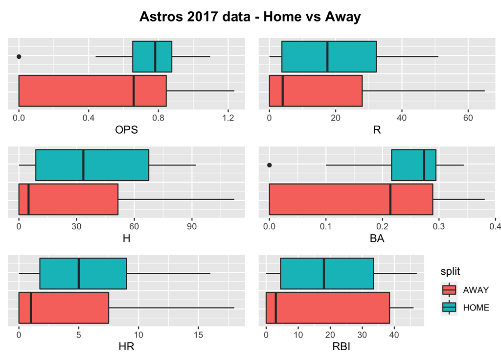

These box plots show how there is a clear difference between home and away games. The largest difference is in average Hits (H) per season that a player gets between home and away games.

### *Runs analysis - Home vs. Away*

To do this analysis, we will be doing a monte carlo simulation on the difference of average runs a player gets per season between home and away games. Runs will be modeled by a poisson random variable. Under the assumption that Runs from home and away games comes from the same distribution, we will set lambda as the mean of runs for home and away games combined.

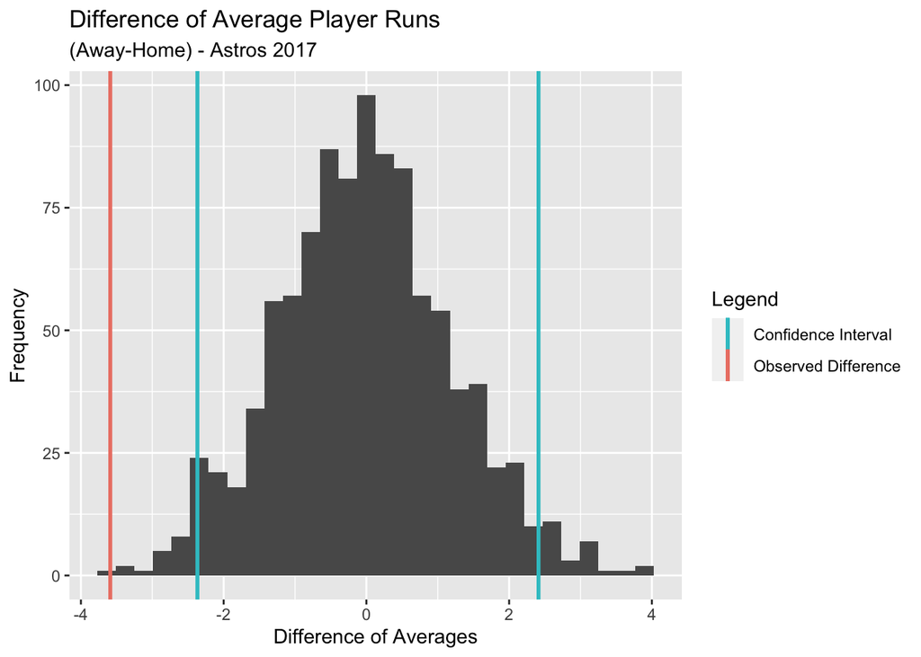

After performing a 95% confidence interval on our data, we see that our observed difference falls outside of the confidence interval, leading us to reject our initial assumption. Thus, we can say with 95% confidence that there is statistical significance in the difference of Run means between home and away games.

### *Is It Just a Home-Field Advantage*

Since our original statistical question is basically “can we prove that the Astros cheated in the 2017 season?” we want to determine if the results we found in the confidence interval above just prove that a home field advantage exists or if the Astros have a better home field advantage due to the existence of cheating.

To do this we will perform some two sample t tests to determine a difference between the average statistics between Astros at home and other teams at their home stadium. We have realized that sign stealing should have a higher effect on players batting averages because it allowed the astros players to know which kind of pitch was coming in and thus have a better chance at hitting the ball. Batting Average is calculated as $BA = Hits / At Bats$.

```
##
##  Welch Two Sample t-test
##
## data:  astros_home$BA and astros_away$BA
## t = 2.2676, df = 48.977, p-value = 0.0278
## alternative hypothesis: true difference in means is not equal to 0
## 95 percent confidence interval:
##  0.007848595 0.130125598
## sample estimates:
## mean of x mean of y
## 0.2466000 0.1776129
```

Above we see that the batting average of the Astros is significantly better at home than away. This again does not show conclusive evidence that they cheated, but instead adds strength to our earlier analysis that the Astros definitely have some sort of a home field advantage. Next we will compare the Astros with the rest of the league, by performing another two sample t test between the astros home games and the home games of all other teams in the league.

```
##
##  Welch Two Sample t-test
##
## data:  astros_home$BA and not_astros_home$BA
## t = 1.6987, df = 21.411, p-value = 0.1039
## alternative hypothesis: true difference in means is not equal to 0
## 95 percent confidence interval:
##  -0.007287044  0.072700567
## sample estimates:
## mean of x mean of y
## 0.2466000 0.2138932
```

Here the results do not lead us anywhere conclusive as our p-value is too high to reject the hypothesis that the true mean of the distribution of the Astros batting average is the same as the true mean of the batting average of all other teams. We have also tried this in other variables in our data set as well, however the results have all been similar. There is no distinction between the astros home statistics versus other teams home statistics.

### *A New Approach*

So far it seems that our data is too general for our statistical question. There are a myriad of different factors that play into how a team does in a season, differing game to game. We believe that to tackle this question we need to take a loot at more in-depth statistics than just player hits, batting average, etc. We have found a new dataset from “Baseball Savant” that offer’s player data for the percent of pitches that are out of the strike zone that a player swings at and the percent of pitches that are in the strike zone that a player swings at.

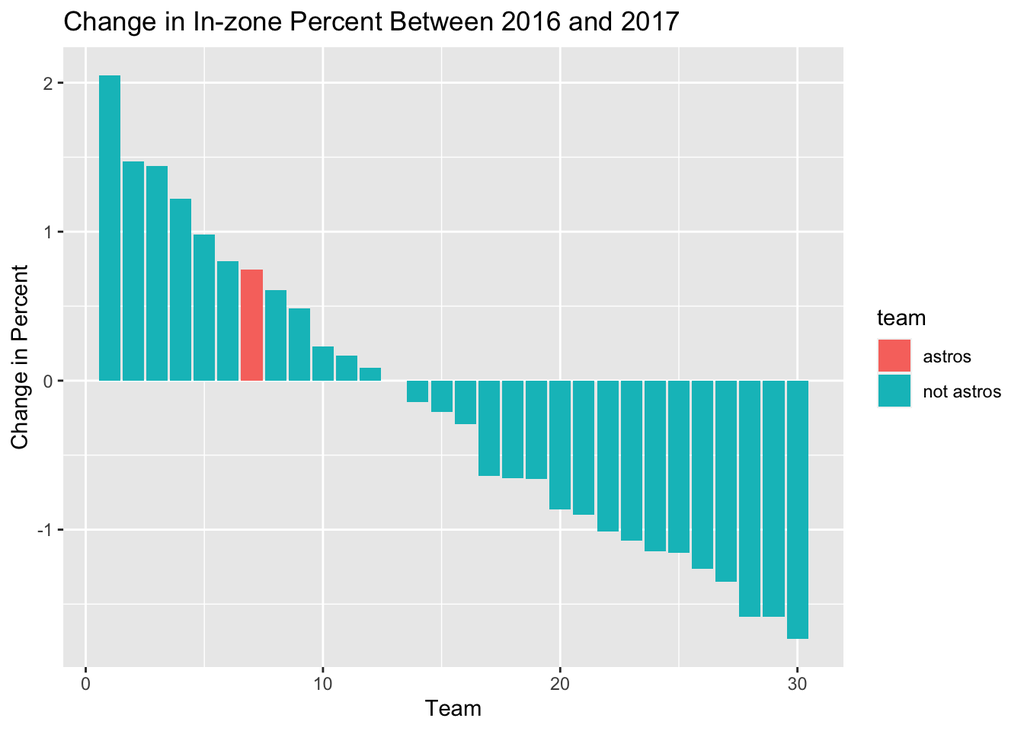

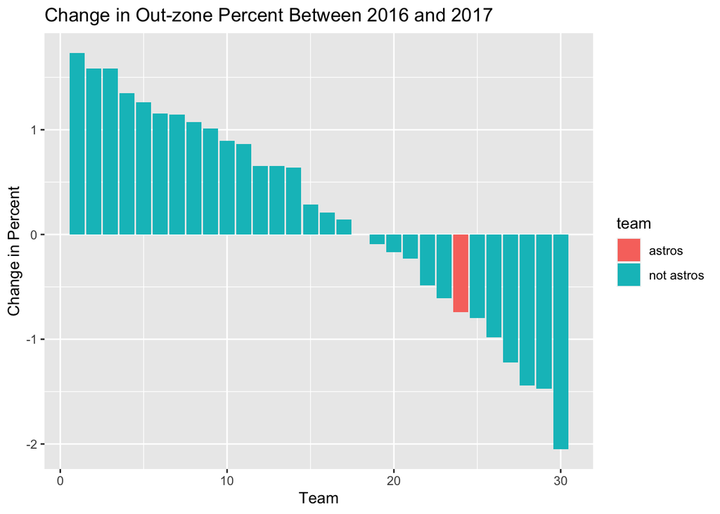

These two graphs so the change in Out-zone percent and In-zone percent between 2016 and 2017 for each team. We highlighted the Astros in red to distinguish them from the rest of the teams. A positive increase in In-zone percentage means that a team is swinging at more pitches that are thrown in the strike zone. A positive increase in Out-zone percentage means that a team is swinging at more pitches that are thrown outside the strike zone than the year previous. For a team to have improved from the year before the will want to increase their in-zone percent and decrease their out-zone percent. Here we can see that the Astros have done this, however it doesn’t look like they have improved a significant amount compared to other teams as their change for both in-zone and out-zone is within 1 percent.

## Conclusion

We have a tried a lot of different things, however most of them do not lead us anywhere significant in trying to answer if the 2017 Houston Astros cheated or not. We have shown that the Astros do have a home field advantage, however the sort of home field advantage that they have does not seem out of the ordinary when compared to other teams. We have also seen that their batting seems to have improved between the 2016 and 2017 season, but they again do not seem to have improved drastically in comparison to the other teams. Overall, there are hundreds of variables that play into how a team does in a season. Perhaps, the Houston Astros truly improved and should’ve won during the 2017 season even without cheating, or maybe their cheating helped boost their confidence. But the data that we would need to prove this is hard to obtain and is most likely only able to be obtained by the major league teams statistician. Although we weren’t able to come to a conclusive result, we were able to see there is some aspect that goes into having a home field advantage, but its very hard to single out just one variable.

Some potential questions that we would want to further look into is what statistical advantage did the Astros actually gained from stealing the signs of the other teams throughout the season. Instead of looking at overall games, we could at specific aspects of the game that was improved upon by each player in the home games.